# Análise Conjunta das Bases Scopus e Web of Science

Claudiano Cruz Neto

20/02/2022

# Importando base de dados

```r
file_scopus <- "https://github.com/cccneto/PSA/blob/master/data/scopus_full.bib?raw=true"
file_web <- "https://github.com/cccneto/PSA/blob/master/data/savedrecs_web.bib?raw=true"
```

# convertendo em dataframes

```r
M_web <- convert2df(file = file_web, dbsource = "wos", format = "bibtex")
```

```
##
## Converting your wos collection into a bibliographic dataframe
##
## Done!
##
##
## Generating affiliation field tag AU_UN from C1:  Done!
```

```r
M_scopus <- convert2df(file = file_scopus, dbsource = "scopus", format = "bibtex")
```

```
##
## Converting your scopus collection into a bibliographic dataframe
##
## Done!
##
##
## Generating affiliation field tag AU_UN from C1:  Done!
```

# Realizando a junção e retirando observações duplicadas

```r
M <- mergeDbSources(M_web, M_scopus, remove.duplicated=TRUE) # o resultado é 220 x 29
```

```
##
##  60 duplicated documents have been removed
```

## Descrição das variáveis

- AU - AutoreS
- TI - Título do documento de
- SO - Nome da Publicação (ou Fonte)
- JI - Abreviatura da fonte ISO
- DT - Tipo de documento
- DE - Palavras-chave dos Autores
- ID - Palavras-chave de associadas pelo banco de dados SCOPUS ou ISI
- AB - Resumo
- C1 - Endereço do Autor
- RP - Endereço de reimpressão
- CR - Referências citadas
- TC - Tempos de citados
- PY - Ano
- SC - Categoria de assunto
- UT - Identificador de artigo exclusivo da
- BD - Banco de Dados Bibliográfico

```r
# Salvando a base no formato compatível com R para evitar possiveis erros no shinypp
# saveRDS(M, file = "bibliometric_data.rds")
```

```r
# rodando shinyapps
# bibliometrix::biblioshiny()
```

## Análise Bibliométrica da Base

```r
results <- biblioAnalysis(M, sep = ";")
```

O primeiro passo é realizar uma análise descritiva do quadro de dados bibliográficos. A função biblioAnalysis calcula as principais medidas bibliométricas usando esta sintaxe:

- Articles - o número total de manuscritos
- Authors - a distribuição de frequência dos autores
- AuthorsFrac - a distribuição de frequência dos autores (fracionada)
- FirstAuthors - autor correspondente de cada manuscrito
- nAUperPaper - o número de autores por manuscrito
- Appearances - o número de aparições do autor
- nAuthors - o número de autores
- AuMultiAuthoredArt - o número de autores de artigos com vários autores
- MostCitedPapers - a lista de manuscritos classificados por citações
- Years - ano de publicação de cada manuscrito
- FirstAffiliation - a afiliação do autor correspondente
- Affiliations - a distribuição de frequência de afiliações (de todos os coautores para cada artigo)
- Aff_frac - a distribuição de frequência fracionada de afiliações (de todos os coautores de cada artigo)
- CO o país de afiliação do autor correspondente
- Countries - a distribuição de frequência dos países afiliados
- CountryCollaboration - os índices de colaboração intra-país (SCP) e inter-países (MCP)
- TotalCitation - o número de vezes que cada manuscrito foi citado
- TCperYear - o número médio anual de vezes que cada manuscrito foi citado
- Sources - a distribuição de frequência das fontes (revistas, livros, etc.)
- DE - a distribuição de frequência das palavras-chave dos autores
- ID - a distribuição de frequência das palavras-chave associadas ao manuscrito pelas bases de dados SCOPUS e Thomson Reuters’ ISI Web of Knowledge

```r
options(width=100)
S <- summary(object = results, k = 10, pause = FALSE)
```

```
##
##
## MAIN INFORMATION ABOUT DATA
##
##  Timespan                              2005 : 2022
##  Sources (Journals, Books, etc)        111
##  Documents                             220
##  Average years from publication        5.42
##  Average citations per documents       38.56
##  Average citations per year per doc    4.253
##  References                            9587
##
## DOCUMENT TYPES
##  article                         195
##  article; early access           1
##  article; proceedings paper      2
##  book                            1
##  book chapter                    3
##  conference review               1
##  editorial material              5
##  review                          12
##
## DOCUMENT CONTENTS
##  Keywords Plus (ID)                    681
##  Author's Keywords (DE)                663
##
## AUTHORS
##  Authors                               783
##  Author Appearances                    1033
##  Authors of single-authored documents  19
##  Authors of multi-authored documents   764
##
## AUTHORS COLLABORATION
##  Single-authored documents             25
##  Documents per Author                  0.281
##  Authors per Document                  3.56
##  Co-Authors per Documents              4.7
##  Collaboration Index                   3.92
##
##
```

[output cut: 102 more lines]

```
##
##
## Most Relevant Keywords
##
##              Author Keywords (DE)      Articles Keywords-Plus (ID)     Articles
## 1  DEFORESTATION                             24 ENVIRONMENTAL SERVICES       55
## 2  ECOSYSTEM SERVICES                        22 CONSERVATION                 48
## 3  PAYMENTS FOR ENVIRONMENTAL SERVICES       22 ECOSYSTEM SERVICES           46
## 4  BRAZIL                                    21 PAYMENTS                     44
## 5  PAYMENT FOR ENVIRONMENTAL SERVICES        19 DEFORESTATION                39
## 6  ENVIRONMENTAL SERVICES                    18 BRAZIL                       26
## 7  REDD                                      16 LAND-USE                     19
## 8  SERVICES                                  16 BIODIVERSITY                 18
## 9  AMAZON                                    14 MANAGEMENT                   17
## 10 CONSERVATION                              14 FOREST                       15
```

## Alguns gráficos para testar:

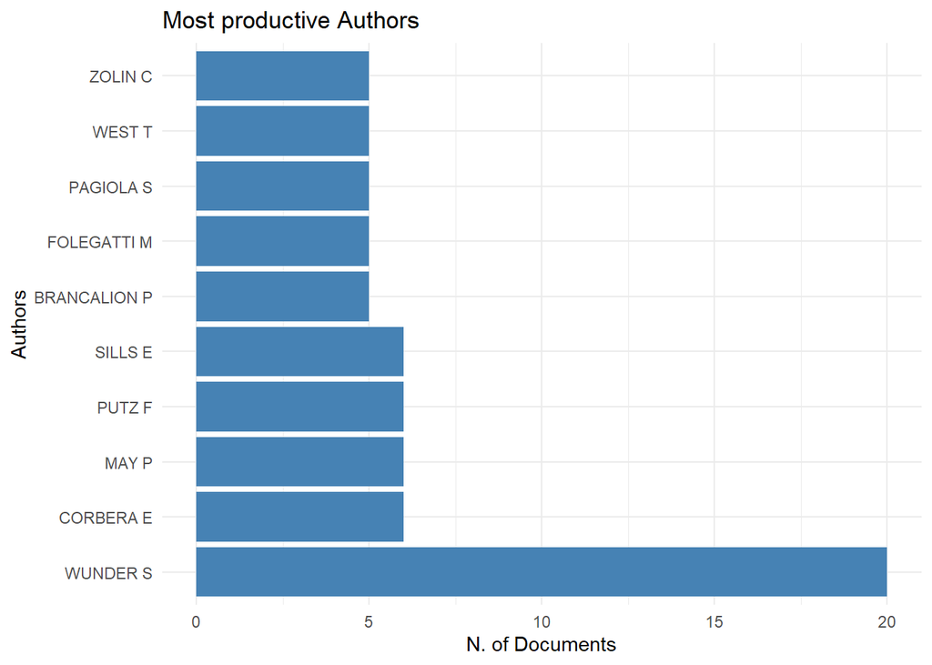

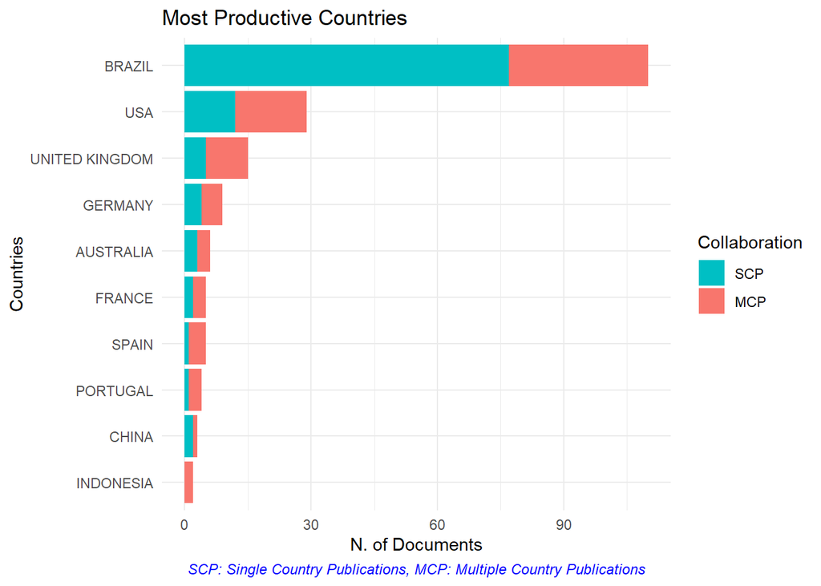

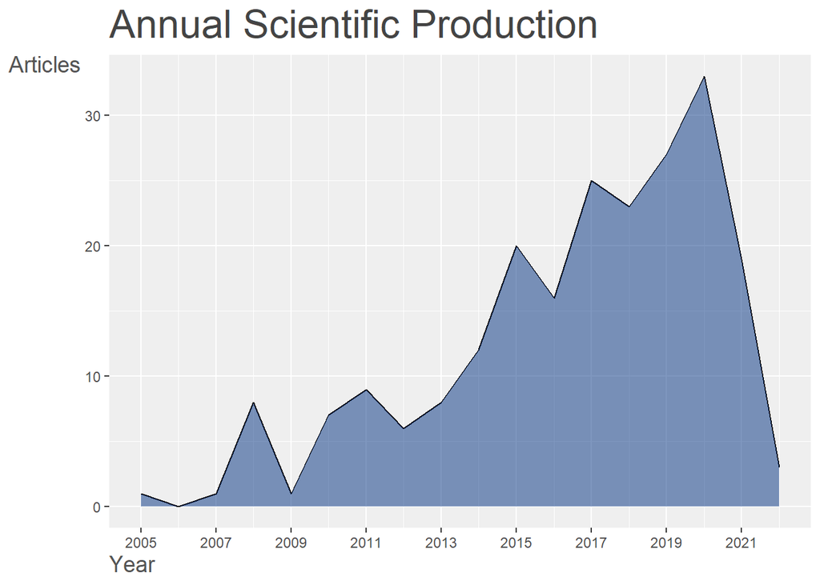

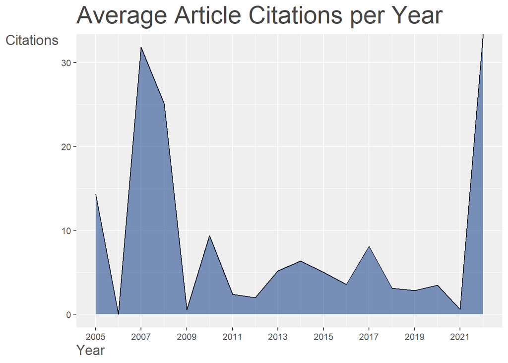

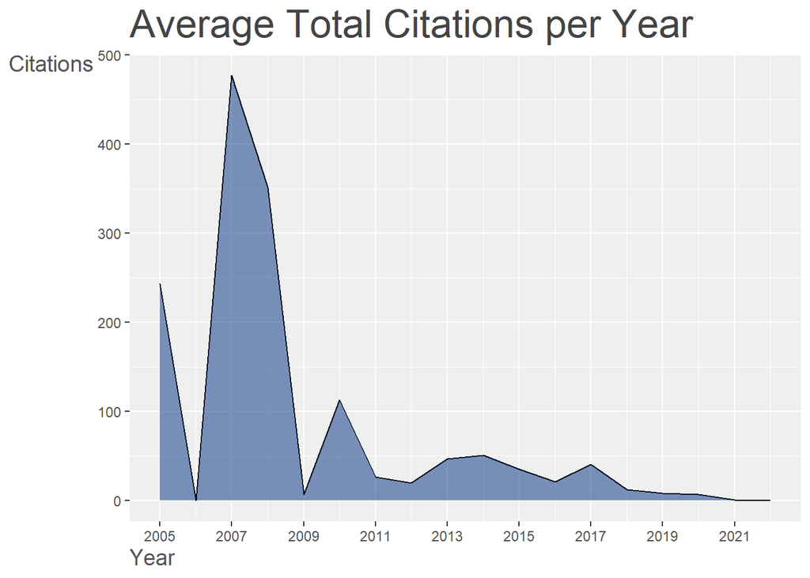

```r
plot(x = results, k = 10, pause = FALSE)
```

## Quais os papers mais citados?

```r
CR <- citations(M, field = "article", sep = ";")
cbind(CR$Cited[1:10])
```

```
##                                                                              [,1]
## ENGEL S, 2008, ECOL ECON, V65, P663, DOI 10.1016/J.ECOLECON.2008.03.011        36
## MURADIAN R, 2010, ECOL ECON, V69, P1202, DOI 10.1016/J.ECOLECON.2009.11.006    34
## PAGIOLA S, 2005, WORLD DEV, V33, P237, DOI 10.1016/J.WORLDDEV.2004.07.011      25
## WUNDER S, 2007, CONSERV BIOL, V21, P48, DOI 10.1111/J.1523-1739.2006.00559.X   25
## PAGIOLA S, 2008, ECOL ECON, V65, P712, DOI 10.1016/J.ECOLECON.2007.07.033      24
## WUNDER S, 2008, ECOL ECON, V65, P834, DOI 10.1016/J.ECOLECON.2008.03.010       24
## RICHARDS RC, 2015, ECOSYST SERV, V16, P23, DOI 10.1016/J.ECOSER.2015.09.002    21
## SOARES B, 2014, SCIENCE, V344, P363, DOI 10.1126/SCIENCE.1246663               20
## FERRARO PJ, 2002, SCIENCE, V298, P1718, DOI 10.1126/SCIENCE.1078104            18
## PATTANAYAK SK, 2010, REV ENV ECON POLICY, V4, P254, DOI 10.1093/REEP/REQ006    17
```

## Para sabermos quais autores são os mais citados:

```r
CR <- citations(M, field = "author", sep = ";")
cbind(CR$Cited[1:10])
```

```
##            [,1]
## WUNDER S    178
## PAGIOLA S   119
## FERRARO PJ   73
## WUNDER       58
## MURADIAN R   53
## ANONYMOUS    50
## BORNER J     50
## ENGEL S      49
## PAGIOLA      48
## ANGELSEN A   44
```

## Para conhecermos os autores locais mais citados:

```r
CR <- localCitations(M, sep = ";")
CR$Authors[1:10,]
```

```
##           Author LocalCitations
## 770     WUNDER S            143
## 232      ENGEL S             64
## 525    PAGIOLA S             60
## 148    CORBERA E             58
## 534    PASCUAL U             49
## 446        MAY P             47
## 371      KOSOY N             45
## 485   MURADIAN R             45
## 605   RICHARDS R             29
## 86  BRANCALION P             24
```

## E os artigos mais citados:

```r
CR$Papers[1:10,]
```

```
##                              Paper                              DOI Year LCS  GCS
## 6         ENGEL S, 2008, ECOL ECON   10.1016/j.ecolecon.2008.03.011 2008  36 1187
## 16     MURADIAN R, 2010, ECOL ECON   10.1016/j.ecolecon.2009.11.006 2010  34  568
## 2     WUNDER S, 2007, CONSERV BIOL 10.1111/j.1523-1739.2006.00559.x 2007  25  477
## 9      WUNDER S, 2008, ECOL ECON-a   10.1016/j.ecolecon.2008.03.010 2008  24  633
## 55 RICHARDS RC, 2015, ECOSYST SERV     10.1016/j.ecoser.2015.09.002 2015  21   58
## 61       WUNDER S, 2015, ECOL ECON   10.1016/j.ecolecon.2014.08.016 2015  15  286
## 1    GRIEG-GRAN M, 2005, WORLD DEV   10.1016/j.worlddev.2005.05.002 2005  13  243
## 36  MURADIAN R, 2013, CONSERV LETT 10.1111/j.1755-263X.2012.00309.x 2013  11  302
## 43     PASCUAL U, 2014, BIOSCIENCE            10.1093/biosci/biu146 2014  11  284
## 5      ASQUITH NM, 2008, ECOL ECON   10.1016/j.ecolecon.2007.12.014 2008   8  169
```

## Ranking de dominância dos autores

```r
DF <- dominance(results, k = 10)
DF
```

```
##          Author Dominance Factor Tot Articles Single-Authored Multi-Authored First-Authored Rank by Articles Rank by DF
## 1        WEST T        1.0000000            5               0              5              5                3          1
## 2      CHIODI R        1.0000000            4               0              4              4                7          1
## 3      COELHO N        1.0000000            4               0              4              4                7          1
## 4       ZOLIN C        0.6000000            5               0              5              3                3          4
## 5     BOERNER J        0.5000000            4               0              4              2                7          5
## 6      BREMER L        0.5000000            4               0              4              2                7          5
## 7     PAGIOLA S        0.4000000            5               0              5              2                3          7
## 8      WUNDER S        0.2222222           20               2             18              4                1          8
## 9  BRANCALION P        0.2000000            5               0              5              1                3          9
## 10    CORBERA E        0.1666667            6               0              6              1                2         10
```

## H-indice dos Autores

O índice h é uma métrica em nível de autor que tenta medir a produtividade e o impacto da citação das publicações de um cientista ou acadêmico. O índice é baseado no conjunto dos trabalhos mais citados do cientista e no número de citações que eles receberam em outras publicações.

A função Hindex calcula o índice H dos autores ou o índice H das fontes e suas variantes (índice g e índice m) em uma coleção bibliográfica. Para calcular o índice h de Lutz Bornmann nesta coleção:

```r
indices <- Hindex(M, field = "author", elements="BORNMANN L", sep = ";", years = 10)

# Bornmann's impact indices:
indices$H
```

```
## [1] Element  h_index  g_index  m_index  TC       NP       PY_start
## <0 linhas> (ou row.names de comprimento 0)
```

Para calcular o índice h dos 10 primeiros autores mais produtivos (nesta coleção):

```r
authors=gsub(","," ",names(results$Authors)[1:10])

indices <- Hindex(M, field = "author", elements=authors, sep = ";", years = 50)

indices$H
```

```
##         Element h_index g_index   m_index   TC NP PY_start
## 1  BRANCALION P       4       5 0.4444444  251  5     2014
## 2     CORBERA E       6       6 0.4615385 1482  6     2010
## 3   FOLEGATTI M       3       4 0.2500000   32  4     2011
## 4         MAY P       5       6 0.3846154 1614  6     2010
## 5     PAGIOLA S       3       4 0.2000000 1826  4     2008
## 6        PUTZ F       5       6 1.0000000   57  6     2018
## 7       SILLS E       6       6 0.6666667  167  6     2014
## 8        WEST T       5       5 1.0000000   77  5     2018
## 9      WUNDER S      17      19 0.9444444 4461 19     2005
## 10      ZOLIN C       3       4 0.2500000   32  4     2011
```

## Produtividade dos principais autores ao longo do tempo

[figure not shown]

```r
topAU <- authorProdOverTime(M, k = 10, graph = TRUE)
```

## Tabela Produtividade do autor por ano

```r
head(topAU$dfAU)
```

```
##         Author year freq  TC      TCpY
## 1 BRANCALION P 2014    2 100 11.111111
## 2 BRANCALION P 2015    2 148 18.500000
## 3 BRANCALION P 2018    1   3  0.600000
## 4    CORBERA E 2010    1 568 43.692308
## 5    CORBERA E 2011    1  80  6.666667
## 6    CORBERA E 2013    1 302 30.200000
```

## Estimativa do coeficiente da Lei de Lotka

A função lotka estima os coeficientes da lei de Lotka para produtividade científica (Lotka A.J., 1926). A lei de Lotka descreve a frequência de publicação por autores em qualquer campo como uma lei do inverso do quadrado, onde o número de autores que publicam um certo número de artigos é uma razão fixa para o número de autores que publicam um único artigo. Essa suposição implica que o coeficiente beta teórico da lei de Lotka é igual a 2.

Utilizando a função lotka é possível estimar o coeficiente Beta de nosso acervo bibliográfico e avaliar, por meio de um teste estatístico, a similaridade desta distribuição empírica com a teórica.

```r
L <- lotka(results)

# Produtividade do autor. Distribuição Empírica
L$AuthorProd
```

```
##   N.Articles N.Authors        Freq
## 1          1       633 0.808429119
## 2          2       101 0.128991060
## 3          3        27 0.034482759
## 4          4        12 0.015325670
## 5          5         5 0.006385696
## 6          6         4 0.005108557
## 7         20         1 0.001277139
```

```r
# Estimativa do Coeficiente Beta
L$Beta
```

```
## [1] 2.23226
```

```r
# Constante
L$C
```

```
## [1] 0.4606375
```

```r
# Qualidade de Ajuste
L$R2
```

```
## [1] 0.9338021
```

```r
# Valor P do teste de duas amostras K-S
L$p.value
```

```
## [1] 0.9375027
```

A tabela ‘L$AuthorProd’ mostra a distribuição observada da produtividade científica.

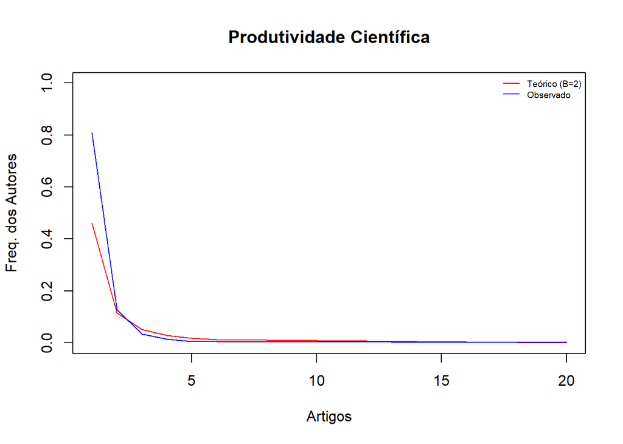

```r
# Distribuição Observada
Observed=L$AuthorProd[,3]

# Distribuição Teórica com Beta = 2
Theoretical=10^(log10(L$C)-2*log10(L$AuthorProd[,1]))

plot(L$AuthorProd[,1],Theoretical,type="l",col="red",ylim=c(0, 1), xlab="Artigos",ylab="Freq. dos Autores",main="Produtividade Científica")
lines(L$AuthorProd[,1],Observed,col="blue")
legend(x="topright",c("Teórico (B=2)","Observado"),col=c("red","blue"),lty = c(1,1,1),cex=0.6,bty="n")
```

## Matrizes de redes bibliográficas

Os atributos do manuscrito estão ligados entre si através do próprio manuscrito: autor(es) para periódico, palavras-chave para data de publicação, etc. Essas conexões de diferentes atributos geram redes bipartidas que podem ser representadas como matrizes retangulares (Manuscritos x Atributos).

Além disso, as publicações científicas contêm regularmente referências a outros trabalhos científicos. Isso gera uma rede adicional, ou seja, rede de cocitação ou acoplamento. Essas redes são analisadas para capturar propriedades significativas do sistema de pesquisa subjacente e, em particular, para determinar a influência de unidades bibliométricas, como acadêmicos e periódicos.

### Redes bipartidas

cocMatrix é uma função geral para calcular uma rede bipartida selecionando um dos atributos de metadados. Por exemplo, para criar uma rede Manuscrito x Fonte de Publicação você deve usar a tag de campo “SO”:

```r
A <- cocMatrix(M, Field = "SO", sep = ";")
```

```r
# Classificando, em ordem decrescente, as somas das colunas de A, tem-se as fontes de publicação mais relevantes:
sort(Matrix::colSums(A), decreasing = TRUE)[1:5]
```

```
##             ECOLOGICAL ECONOMICS               ECOSYSTEM SERVICES ENGENHARIA SANITARIA E AMBIENTAL
##                               19                               11                               11
##  DESENVOLVIMENTO E MEIO AMBIENTE                  LAND USE POLICY
##                                7                                6
```

Seguindo essa abordagem, você pode calcular várias redes bipartidas:

```r
# Rede de Citações
A <- cocMatrix(M, Field = "CR", sep = ".  ")
```

```r
# Rede de Autores
 A <- cocMatrix(M, Field = "AU", sep = ";")
```

```r
# Rede de paises
M <- metaTagExtraction(M, Field = "AU_CO", sep = ";")
A <- cocMatrix(M, Field = "AU_CO", sep = ";")
```

```r
# Rede de palavras-chave do autor
A <- cocMatrix(M, Field = "DE", sep = ";")
```

```r
# Rede de Palavras chave +
A <- cocMatrix(M, Field = "ID", sep = ";")
```

### Calculando a rede clássica de acoplamento dos artigos

```r
NetMatrix <- biblioNetwork(M, analysis = "coupling", network = "references", sep = ".  ")
```

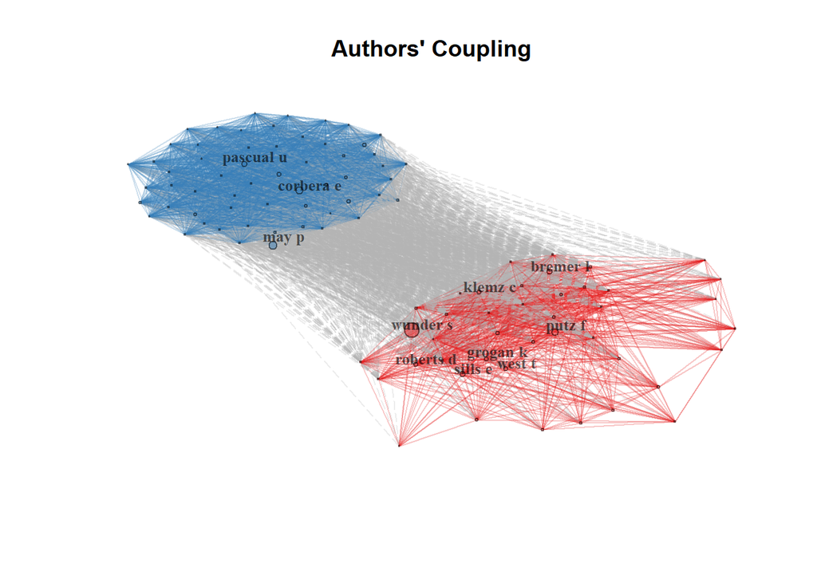

```r
NetMatrix <- biblioNetwork(M, analysis = "coupling", network = "authors", sep = ";")

net=networkPlot(NetMatrix,  normalize = "salton", weighted=NULL, n = 100, Title = "Authors' Coupling", type = "fruchterman", size=5,size.cex=T,remove.multiple=TRUE,labelsize=0.8,label.n=10,label.cex=F)
```

### Co-citação bibliográfica

```r
NetMatrix <- biblioNetwork(M, analysis = "co-citation", network = "references", sep = ".  ")
```

### Colaboração Bibliográfica

```r
NetMatrix <- biblioNetwork(M, analysis = "collaboration", network = "authors", sep = ";")
```

```r
NetMatrix <- biblioNetwork(M, analysis = "collaboration", network = "countries", sep = ";")
```

## Análise descritiva das características do gráfico de rede

```r
# Rede clássica de coocorrências de palavras-chave
NetMatrix <- biblioNetwork(M, analysis = "co-occurrences", network = "keywords", sep = ";")
netstat <- networkStat(NetMatrix)
```

## As estatísticas resumidas da rede

Este grupo de estatísticas permite descrever as propriedades estruturais de uma rede:

- *Size* é o número de vértices que compõem a rede;
- *Density* é a proporção de arestas presentes de todas as arestas possíveis na rede;
- *Transitivity* é a razão de triângulos para triplos conectados;
- *Diameter* é a distância geodésica mais longa (comprimento do caminho mais curto entre dois nós) na rede;
- *Degree distribution* é a distribuição cumulativa dos graus dos vértices;
- *Degree Centralization* é o grau normalizado da rede geral;
- *Closeness centralization* é o inverso normalizado da distância geodésica média do vértice para outros na rede;
- *Eigenvector centralization* é o primeiro autovetor da matriz do gráfico;
- *Betweenness centralization* é o número normalizado de geodésicas que passam pelo vértice;
- *Average path length* é a média da distância mais curta entre cada par de vértices na rede.

```r
names(netstat$network)
```

```
##  [1] "networkSize"             "networkDensity"          "networkTransitivity"     "networkDiameter"
##  [5] "networkDegreeDist"       "networkCentrDegree"      "networkCentrCloseness"   "networkCentrEigen"
##  [9] "networkCentrbetweenness" "NetworkAverPathLeng"
```

### Colaboração Científica do País

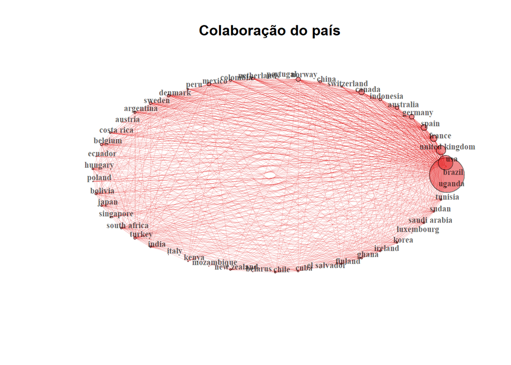

```r
M <- metaTagExtraction(M, Field = "AU_CO", sep = ";")
NetMatrix <- biblioNetwork(M, analysis = "collaboration", network = "countries", sep = ";")

# Plotando a rede
net=networkPlot(NetMatrix, n = dim(NetMatrix)[1], Title = "Colaboração do país", type = "circle", size=TRUE, remove.multiple=FALSE,labelsize=0.7,cluster="none")
```

### Criar rede de coocorrências de palavras-chave

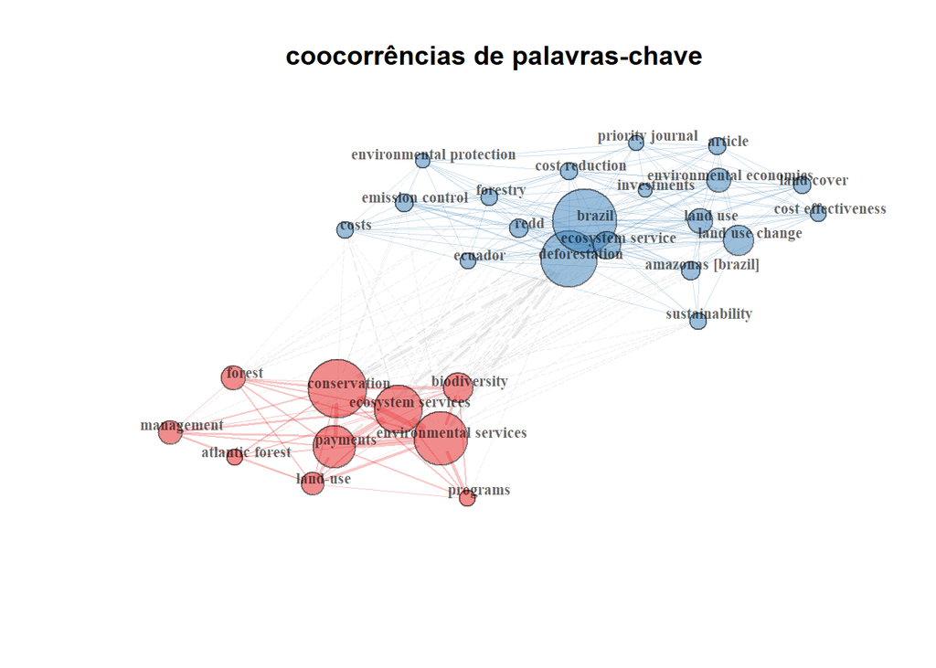

```r
# Criar rede de coocorrências de palavras-chave

NetMatrix <- biblioNetwork(M, analysis = "co-occurrences", network = "keywords", sep = ";")

# Plot the network
net=networkPlot(NetMatrix, normalize="association", weighted=T, n = 30, Title = "coocorrências de palavras-chave", type = "fruchterman", size=T,edgesize = 5,labelsize=0.7)
```

### Análise de co-palavras: a estrutura conceitual de um campo

O objetivo da análise de co-palavras é mapear a estrutura conceitual de um framework usando as coocorrências de palavras em uma coleção bibliográfica. A análise pode ser realizada por meio de técnicas de redução de dimensionalidade como Multidimensional Scaling (MDS), Análise de Correspondência (CA) ou Análise de Correspondência Múltipla (MCA).

Aqui, mostramos um exemplo que executa um CA ou MCA para desenhar uma estrutura conceitual do campo e K-means clustering para identificar clusters de documentos que expressam conceitos comuns. Os resultados são plotados em um mapa bidimensional.

```r
# Estrutura conceitual usando palavras-chave (method="CA")

CS <- conceptualStructure(M,field="ID", method="CA", minDegree=4, clust=5, stemming=FALSE, labelsize=10, documents=10)
```

[figure not shown]

[figure not shown]

[figure not shown]

[figure not shown]

### Rede de citações diretas históricas

O mapa historiográfico é um gráfico proposto por E. Garfield (2004) para representar um mapa de rede cronológica das citações diretas mais relevantes resultantes de um acervo bibliográfico. A função gera uma matriz de rede de citação direta cronológica que pode ser plotada usando histPlot:

```r
# Crie uma rede de citações históricas
options(width=130)
histResults <- histNetwork(M, min.citations = 1, sep = ";")
```

```
##
## WOS DB:
## Searching local citations (LCS) by reference items (SR) and DOIs...
##
## Analyzing 11781 reference items...
##
## Found 57 documents with no empty Local Citations (LCS)
```

[figure not shown]

```
##
##  Legend
##
##                                                                  Label                              DOI Year LCS  GCS
## 1     GRIEG-GRAN M, 2005, WORLD DEV DOI 10.1016/J.WORLDDEV.2005.05.002   10.1016/j.worlddev.2005.05.002 2005  13  243
## 2    WUNDER S, 2007, CONSERV BIOL DOI 10.1111/J.1523-1739.2006.00559.X 10.1111/j.1523-1739.2006.00559.x 2007  25  477
## 3       ASQUITH NM, 2008, ECOL ECON DOI 10.1016/J.ECOLECON.2007.12.014   10.1016/j.ecolecon.2007.12.014 2008   8  169
## 4          ENGEL S, 2008, ECOL ECON DOI 10.1016/J.ECOLECON.2008.03.011   10.1016/j.ecolecon.2008.03.011 2008  36 1187
## 5         WUNDER S, 2008, ECOL ECON DOI 10.1016/J.ECOLECON.2007.11.004   10.1016/j.ecolecon.2007.11.004 2008   8  152
## 6         WUNDER S, 2008, ECOL ECON DOI 10.1016/J.ECOLECON.2008.03.010   10.1016/j.ecolecon.2008.03.010 2008  24  633
## 7       MURADIAN R, 2010, ECOL ECON DOI 10.1016/J.ECOLECON.2009.11.006   10.1016/j.ecolecon.2009.11.006 2010  34  568
## 8  MURADIAN R, 2013, CONSERV LETT DOI 10.1111/J.1755-263X.2012.00309.X 10.1111/j.1755-263X.2012.00309.x 2013  11  302
## 9                PASCUAL U, 2014, BIOSCIENCE DOI 10.1093/BIOSCI/BIU146            10.1093/biosci/biu146 2014  11  284
## 10     DUCHELLE AE, 2014, WORLD DEV DOI 10.1016/J.WORLDDEV.2013.01.014   10.1016/j.worlddev.2013.01.014 2014   5   90
## 11    RICHARDS RC, 2015, ECOSYST SERV DOI 10.1016/J.ECOSER.2015.09.002     10.1016/j.ecoser.2015.09.002 2015  21   58
## 12        WUNDER S, 2015, ECOL ECON DOI 10.1016/J.ECOLECON.2014.08.016   10.1016/j.ecolecon.2014.08.016 2015  15  286
## 13      BREMER LL, 2016, ECOSYST SERV DOI 10.1016/J.ECOSER.2015.12.006     10.1016/j.ecoser.2015.12.006 2016   7   61
## 14    RICHARDS RC, 2017, ECOSYST SERV DOI 10.1016/J.ECOSER.2016.12.016     10.1016/j.ecoser.2016.12.016 2017   7   20
## 15      DE LIMA LS, 2019, ECOL ECON DOI 10.1016/J.ECOLECON.2018.09.005   10.1016/j.ecolecon.2018.09.005 2019   5   12
```

```r
# Traçar uma rede de cocitação histórica
net <- histPlot(histResults, n=15, size = 10, labelsize=5)
```